# Praca Domowa

Adam Rydelek, Piotr Miziński

26 marca 2019

# 1 Wprowadzenie

## 1.1 Sposób odczytu danych

Do odczytania potrzebnych nam plików wykorzystaliśmy komendę *list.files*, oraz odpowiedni pattern. Następnie sczytaliśmy dane do ramki danych za pomocą funkcji *fromJSON* z pakietu `jsonlite`. Powstały nam w ten sposób 3 ramki danych stworzone z plików typu **model.json**, **audit.json**, **dataset.json**.

```r
### audit
#pobieramy pliki audit
files <- list.files(pattern = "audit\\.json$", recursive=TRUE)

#data.frame liczba auditow o danej liczbie kolumn i drugi dla błędnych auditów
nc <- data.frame("ncol" = 0)
bledne <- data.frame("nr" = 0)
dobre <- data.frame("nr" = 0)

#data.framy dla regresji i klasyfikacji
dR <- fromJSON(files[1])
dR <- cbind(dR,dR$performance)
dR <- select(dR,-performance)

dC <- fromJSON(files[4])
dC <- cbind(dC,dC$performance)
dC <- select(dC,-performance)

#pętla, żeby miec numery plikow
for(i in 1:length(files)){

  p <- fromJSON(files[i])
  p <- cbind(p,p$performance)
  p <- select(p,-performance)

  names(p) <- tolower(names(p))


  if(ncol(p) == 10){
    if(names(p)[10] == 'rsq'){
      names(p)[10] <- 'r2'
    }

    if(all(names(p) == names(dR))){
      dR <- rbind(dR,p)
      dobre <- rbind(dobre,data.frame("nr" = i))
    }
    else{
      bledne <- rbind(bledne,data.frame("nr" = i))
    }
  }

  if(ncol(p) == 12){
    if(all(names(p) == names(dC))){
      dC <- rbind(dC,p)
      dobre <- rbind(dobre,data.frame("nr" = i))
    }
    else{
      bledne <- rbind(bledne,data.frame("nr" = i))
    }
  }

  if(ncol(p) != 10){
    if(ncol(p) != 12){
      bledne <- rbind(bledne,data.frame("nr" = i))
    }
  }

  nc <- rbind(nc,data.frame("ncol" = ncol(p)))

}

#unique
nc <- unique(nc)[-1,]
bledne <- unique(bledne)[-1,]
dobre <- unique(dobre)[-1,]
dR <- unique(dR)
dC <- unique(dC)


#pobieramy pliki model
filesM <- list.files(pattern = "model\\.json$", recursive=TRUE)

#data.frame liczba modeli o danej liczbie kolumn i drugi dla błędnych modeli
ncM <- data.frame("ncol" = 0)
bledneM <- data.frame("nr" = 0)
dobreM <- data.frame("nr" = 0)

dM <- fromJSON(filesM[1])

#przygotowanie zbioru, pierwszy wiersz
dMClean <- select(dM, id, library, model_name, task_id, dataset_id)
pre <- dM$preprocessing
dMClean$nC <- ncol(pre)

ncat =0
nnum = 0
for(i in names(pre)){
  a<-pre[i]
  a<-a[,1]
  if(a$type == c("categorical")){
    ncat =  ncat + 1
  }
  else{
    nnum = nnum + 1
  }
}

dMClean$ncat <- ncat
dMClean$nnum <- nnum
names(dMClean) <- tolower(names(dMClean))


for(j in 2:length(filesM)){

  dM <- fromJSON(filesM[j])
  pre <- dM$preprocessing

  if(ncol(dM) == 9){
    if(colnames(dM)[5] == "model"){
      colnames(dM)[5] <- "model_name"
    }

    dMCleanH <- select(dM, id, library, model_name, task_id, dataset_id)

    #liczba i rodzaj kolumn
    dMCleanH$nC <- ncol(pre)
    ncat =0
    nnum = 0
    for(i in names(pre)){
      a<-pre[i]
      a<-a[,1]
      if(a$type == c("categorical")){
        ncat =  ncat + 1
      }
      else{
        nnum = nnum + 1
      }
    }

    dMCleanH$ncat <- ncat
    dMCleanH$nnum <- nnum

    #laczenie
    names(dMCleanH) <- tolower(names(dMCleanH))
    if(all(names(dMCleanH) == names(dMClean))){
      dMClean <- rbind(dMClean,dMCleanH)
      dobreM <- rbind(dobreM,data.frame("nr" = j))
    }
    else{
      bledneM <- rbind(bledneM,data.frame("nr" = j))
    }
  }

}

dMClean <- unique(dMClean)

#laczenie zbiorow
kC <- left_join(dC, dMClean, by = c("model_id" = "id"))
kR <- left_join(dR, dMClean, by = c("model_id" = "id"))

kC <- kC[!is.na(kC$model_name),]
mod <- select(kC, -c(id, model_id, task_id.y, dataset_id.y))

mod[sapply(mod, is.character)] <- lapply(mod[sapply(mod, is.character)],
                                         as.factor)
mod <- mod[!is.na(mod$acc),]
mod <- mod[,4:ncol(mod)]
mod <- mod[,-(3:7)]

#dataset.json
filesDS <- list.files(pattern = "dataset\\.json$", recursive=TRUE)

dDS <- fromJSON(filesDS[1])

#przygotowanie zbioru, pierwszy wiersz
dDS <- select(dDS, id, number_of_instances, number_of_missing_values, number_of_instances_with_missing_values)

for(k in 2:length(filesDS)){
  p <- fromJSON(filesDS[k])
  p <- select(p, id, number_of_instances, number_of_missing_values, number_of_instances_with_missing_values)

  dDS <- rbind(dDS,p)
}

data <- left_join(mod, dDS, by = c("dataset_id.x" = "id"))
data <- data[!is.na(data$number_of_instances),]
data <- data[,-1]
data <- data[,-4]
```

## 1.2 Końcowa ramka danych

Następnie odrzuciliśmy błędne wiersze i kolumny, które nie były istotne dla modelu, takie jak jego **task_id**, czy **author**. Uznaliśmy, że skupimy się jedynie na modelach *klasyfikacyjnych*. W ten sposób powstała końcowa ramka danych:

```r
dataShow <- data
colnames(dataShow)[6] <- "instances"
colnames(dataShow)[7] <- "missing values"
colnames(dataShow)[8] <- "missing instances"
DT::datatable(dataShow)
```

|  | acc | library | model_name | ncat | nnum | instances | missing values | missing instances |
| --- | --- | --- | --- | --- | --- | --- | --- | --- |
| 2 | 0.9397 | mlr | classif.svm | 3 | 7 | 800 | 387 | 386 |
| 3 | 0.9203 | mlr | classif.gbm | 3 | 7 | 800 | 387 | 386 |
| 4 | 0.9204 | mlr | classif.rda | 3 | 7 | 800 | 387 | 386 |
| 5 | 0.9324 | mlr | classif.mda | 3 | 7 | 800 | 387 | 386 |
| 6 | 0.6722 | mlr | classif.gbm | 3 | 2 | 150000 | 0 | 0 |
| 7 | 0.6739 | mlr | classif.gbm | 3 | 2 | 150000 | 0 | 0 |
| 8 | 0.6951 | mlr | classif.gbm | 3 | 2 | 150000 | 0 | 0 |
| 9 | 0.8460563 | mlr | classif.randomForest | 0 | 8 | 10218 | 0 | 0 |
| 10 | 0.2263658 | caret | glmnet | 1 | 7 | 10218 | 0 | 0 |
| 11 | 0.3417 | mlr | classif.lda | 1 | 7 | 10218 | 0 | 0 |

[output cut: 247 more lines]

# 2 Metamodel

Jako, że mamy już przygotowane dane, nadszedł czas na wybór modelu. Uznaliśmy, że zrobimy *regresję* na zmiennej **accuracy**, która będzie naszym targetem.

## 2.1 Wybór odpowiedniego modelu

Wybraliśmy 3 modele: `rpart`, `cforest` i `bartMachine` do porównania, które dały następujące wyniki:

```r
DT::datatable(results)
```

|  | rpart | cfortest | bartMachine |
| --- | --- | --- | --- |
| mse.test.mean | 0.0233776198410083 | 0.0200406440525234 | 0.00818327898175173 |
| rmse.test.rmse | 0.152897416070411 | 0.141564981731088 | 0.0904614778883903 |
| mae.test.mean | 0.095040683834364 | 0.0979338481946589 | 0.0472207464392427 |
| rsq.test.mean | 0.209559619836345 | 0.37062049017557 | 0.738007108437137 |

Jak widać po porównaniu miar powyższych modeli najlepiej prezentuje się `bartMachine`.

## 2.2 Przykład predykcji

Aby sprawdzić dokładniej na ile skuteczny jest nasz metamodel postanowiliśmy sprawdzić jego predykcję na nowym modelu i porównać z jego prawdziwym accuracy. Do tego celu stworzyliśmy model **classif.logreg** na ramce danych *openml_boston*, który nie był obecny w zbiorze uczącym/testowym. Następnie wstawiliśmy jego dane do naszego modelu i porównaliśmy z jego wynikami. Rezultat wygląda następująco:

```r
resultOfComparison
```

|  | Prawdziwa_wartosc | Przewidziana_wartosc |
| --- | --- | --- |
| acc.test.mean | 0.8774219 | 0.8778165 |

Można więc zauważyć, że dla tego przykładu model przewidział accuracy z bardzo dobrą dokładnością.

# 3 Wizualizacja modelu

Aby zrozumieć działanie naszego wybranego modelu - *bartMachine* i porównać go z gorszym *rpart* wykorzystaliśmy pakiet `DALEX`.

## 3.1 Ważność zmiennych

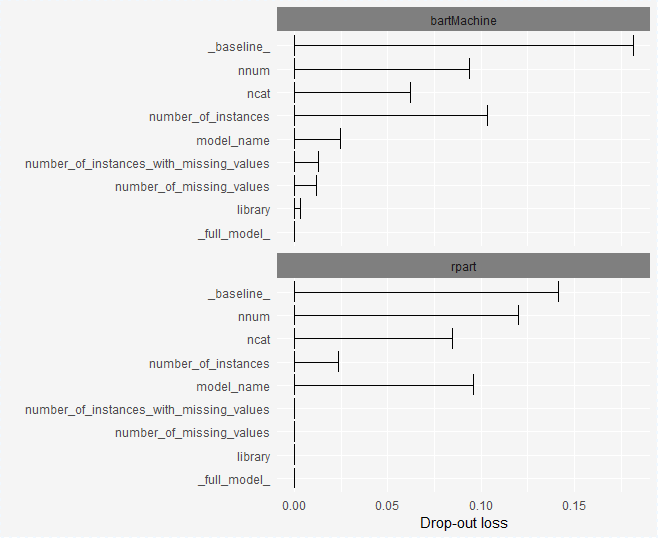

## 3.2 Wpływ liczby kategorii na predykcję

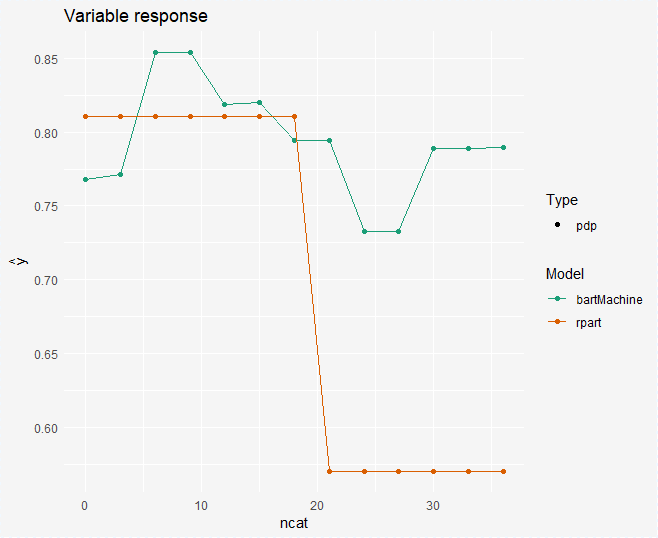

## 3.3 Rozkład rezyduum

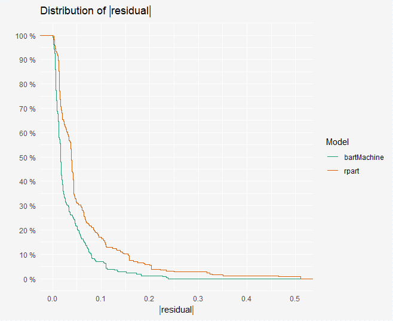

## 3.4 Porównanie accuracy i predicted accuracy

### 3.4.1 rpart

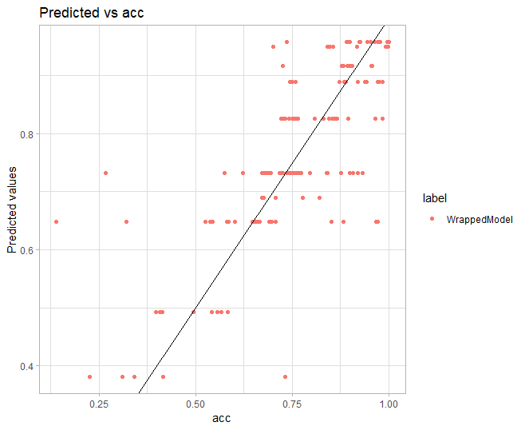

### 3.4.2 bartMachine

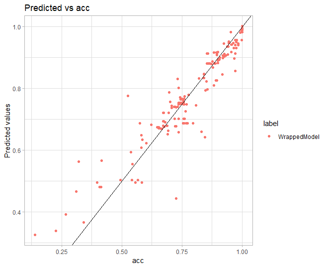

## 3.5 Podział na grupy w zależności od stosowanego modelu

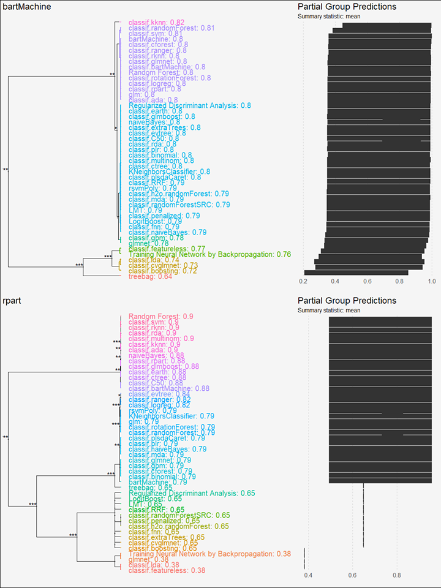